# Online Retail Customer Segmentation

## 1. Dataset Summary

This is an online retail store dataset which contains transactions occuring in 1-year period, between Dec 1st 2010 and Dec 9th 2011. Many customers of the company are wholesalers. This dataset contains 541k rows and 8 columns, described below.

- InvoiceNo: Invoice number. Nominal, a 6-digit integral number uniquely assigned to each transaction. If this code starts with letter 'c', it indicates a cancellation.
- StockCode: Product (item) code. Nominal, a 5-digit integral number uniquely assigned to each distinct product.
- Description: Product (item) name. Nominal.
- Quantity: The quantities of each product (item) per transaction. Numeric.
- InvoiceDate: Invice Date and time. Numeric, the day and time when each transaction was generated.
- UnitPrice: Unit price. Numeric, Product price per unit in sterling.
- CustomerID: Customer number. Nominal, a 5-digit integral number uniquely assigned to each customer.
- Country: Country name. Nominal, the name of the country where each customer resides.

The numerical features are UnitPrice and Quantity, while the rest are `object` data type or categorical features.

Dataset [source](https://archive.ics.uci.edu/ml/datasets/online+retail):

Daqing Chen, Sai Liang Sain, and Kun Guo, Data mining for the online retail industry: A case study of RFM model-based customer segmentation using data mining, Journal of Database Marketing and Customer Strategy Management, Vol. 19, No. 3, pp. 197â€“208, 2012 (Published online before print: 27 August 2012. doi: 10.1057/dbm.2012.17)

```python
# Import PyDrive and associated libraries.
# This only needs to be done once per notebook.
from pydrive.auth import GoogleAuth
from pydrive.drive import GoogleDrive
from google.colab import auth
from oauth2client.client import GoogleCredentials

# Authenticate and create the PyDrive client.
# This only needs to be done once per notebook.
auth.authenticate_user()
gauth = GoogleAuth()
gauth.credentials = GoogleCredentials.get_application_default()
drive = GoogleDrive(gauth)

# Download a file based on its file ID.
#
# A file ID looks like: laggVyWshwcyP6kEI-y_W3P8D26sz
file_id = '1BRvg_ZubjFpciAhFA_Qaj1EZkaIWOITs'
downloaded = drive.CreateFile({'id': file_id})
# print('Downloaded content "{}"'.format(downloaded.GetContentString()))
downloaded.GetContentFile('Online Retail.csv')
```

```python
import numpy as np
import pandas as pd
import matplotlib.pyplot as plt
import matplotlib.cm as cm
import seaborn as sns
from datetime import timedelta
# import warnings
# warnings.simplefilter(action='ignore', category='SettingWithCopyWarning')
sns.set()
```

```python
from sklearn.preprocessing import StandardScaler
from sklearn.cluster import KMeans, AgglomerativeClustering
from sklearn.metrics import silhouette_score, silhouette_samples
from scipy.spatial.distance import cdist
from sklearn.manifold import TSNE
from sklearn.decomposition import PCA
```

```python
def check_values(df):
    col_desc = []
    data = {
        'features': [col for col in df.columns],
        'data_type': [df[col].dtype for col in df.columns],
        'nan_total': [df[col].isna().sum() for col in df.columns],
        'nan_pct': [round(df[col].isna().sum()/len(df)*100,2) for col in df.columns],
        'unique': [df[col].nunique() for col in df.columns],
        'values_ex': [df[col].drop_duplicates().sample(df[col].nunique()).values if df[col].nunique() <= 5 else df[col].drop_duplicates().sample(2).values for col in df.columns]
    }
    return pd.DataFrame(data)
```

```python
%%time
# filepath = r'C:\Users\azuka\Drive Folder\ML projects\Leapsapp\customer segmentation kmeans\Online Retail.csv'
data = pd.read_csv('Online Retail.csv')
data
```

```
CPU times: user 607 ms, sys: 28 ms, total: 635 ms
Wall time: 649 ms
```

Check data type, missing values, and unique values for each column

```python
%%time
check_values(data)
```

```
CPU times: user 766 ms, sys: 9.17 ms, total: 776 ms
Wall time: 788 ms
```

|  | features | data_type | nan_total | nan_pct | unique | values_ex |
| --- | --- | --- | --- | --- | --- | --- |
| 0 | InvoiceNo | object | 0 | 0.00 | 25900 | [553565, 575490] |
| 1 | StockCode | object | 0 | 0.00 | 4070 | [72132, 84801B] |
| 2 | Description | object | 1454 | 0.27 | 4223 | [OFFICE MUG WARMER PINK, crushed boxes] |
| 3 | Quantity | int64 | 0 | 0.00 | 722 | [768, 99] |
| 4 | InvoiceDate | object | 0 | 0.00 | 23260 | [29/09/2011 9:53, 04/02/2011 14:04] |
| 5 | UnitPrice | float64 | 0 | 0.00 | 1630 | [448.0, 732.69] |
| 6 | CustomerID | float64 | 135080 | 24.93 | 4372 | [16094.0, 17928.0] |
| 7 | Country | object | 0 | 0.00 | 38 | [Lithuania, Australia] |

It seems that there are invalid values, where the Quantity and UnitPrice is negative. We will visit this again shortly.

```python
data.describe()
```

|  | Quantity | UnitPrice | CustomerID |
| --- | --- | --- | --- |
| count | 541909.000000 | 541909.000000 | 406829.000000 |
| mean | 9.552250 | 4.611114 | 15287.690570 |
| std | 218.081158 | 96.759853 | 1713.600303 |
| min | -80995.000000 | -11062.060000 | 12346.000000 |
| 25% | 1.000000 | 1.250000 | 13953.000000 |
| 50% | 3.000000 | 2.080000 | 15152.000000 |
| 75% | 10.000000 | 4.130000 | 16791.000000 |
| max | 80995.000000 | 38970.000000 | 18287.000000 |

## 2. Goals

Group the customer using KMeans, with the help of Recency, Frequency, and Monetary (RFM) analysis

## 3. Data Cleaning and Feature Engineering

### Data Cleaning

- There are many missing values for CustomerID (25%). Remove those rows since we are going to group the transaction based on the CustomerID.
- Remove cancelled transaction records, which `InvoiceNo` starts with 'C'
- Change the InvoiceDate to datetime type.
- Make new feature, TotalSum, as the product of Quantity and UnitPrice

Cancelled Transactions:

```python
data[data.InvoiceNo.str.startswith('C')]
```

|  | InvoiceNo | StockCode | Description | Quantity | InvoiceDate | UnitPrice | CustomerID | Country |
| --- | --- | --- | --- | --- | --- | --- | --- | --- |
| 141 | C536379 | D | Discount | -1 | 01/12/2010 9:41 | 27.50 | 14527.0 | United Kingdom |
| 154 | C536383 | 35004C | SET OF 3 COLOURED FLYING DUCKS | -1 | 01/12/2010 9:49 | 4.65 | 15311.0 | United Kingdom |
| 235 | C536391 | 22556 | PLASTERS IN TIN CIRCUS PARADE | -12 | 01/12/2010 10:24 | 1.65 | 17548.0 | United Kingdom |
| 236 | C536391 | 21984 | PACK OF 12 PINK PAISLEY TISSUES | -24 | 01/12/2010 10:24 | 0.29 | 17548.0 | United Kingdom |
| 237 | C536391 | 21983 | PACK OF 12 BLUE PAISLEY TISSUES | -24 | 01/12/2010 10:24 | 0.29 | 17548.0 | United Kingdom |
| ... | ... | ... | ... | ... | ... | ... | ... | ... |
| 540449 | C581490 | 23144 | ZINC T-LIGHT HOLDER STARS SMALL | -11 | 09/12/2011 9:57 | 0.83 | 14397.0 | United Kingdom |
| 541541 | C581499 | M | Manual | -1 | 09/12/2011 10:28 | 224.69 | 15498.0 | United Kingdom |
| 541715 | C581568 | 21258 | VICTORIAN SEWING BOX LARGE | -5 | 09/12/2011 11:57 | 10.95 | 15311.0 | United Kingdom |
| 541716 | C581569 | 84978 | HANGING HEART JAR T-LIGHT HOLDER | -1 | 09/12/2011 11:58 | 1.25 | 17315.0 | United Kingdom |
| 541717 | C581569 | 20979 | 36 PENCILS TUBE RED RETROSPOT | -5 | 09/12/2011 11:58 | 1.25 | 17315.0 | United Kingdom |

9288 rows × 8 columns

New features (TotalSum)

```python
%%time
df_clean = data.dropna(subset=['CustomerID'])
cancelled = df_clean[df_clean.InvoiceNo.str.startswith('C')].index
df_clean = df_clean.drop(index=cancelled)
df_clean.loc[:,'Date'] = pd.to_datetime(df_clean['InvoiceDate'])
df_clean.loc[:,'TotalSum'] = df_clean['Quantity'] * df_clean['UnitPrice']
df_clean[['Quantity', 'UnitPrice', 'TotalSum']].head()
```

```
CPU times: user 2.85 s, sys: 29.3 ms, total: 2.88 s
Wall time: 2.92 s
```

The final dataset contains 397k rows with no more missing values.

```python
print('df_clean length:',len(df_clean))
```

```
df_clean length: 397924
```

```python
%%time
check_values(df_clean)
```

```
CPU times: user 599 ms, sys: 7.9 ms, total: 607 ms
Wall time: 609 ms
```

|  | features | data_type | nan_total | nan_pct | unique | values_ex |
| --- | --- | --- | --- | --- | --- | --- |
| 0 | InvoiceNo | object | 0 | 0.0 | 18536 | [566633, 556792] |
| 1 | StockCode | object | 0 | 0.0 | 3665 | [21191, 16238] |
| 2 | Description | object | 0 | 0.0 | 3877 | [PENCIL CASE LIFE IS BEAUTIFUL, DOORSTOP FOOTB... |
| 3 | Quantity | int64 | 0 | 0.0 | 302 | [608, 407] |
| 4 | InvoiceDate | object | 0 | 0.0 | 17286 | [07/07/2011 10:28, 04/12/2011 12:18] |
| 5 | UnitPrice | float64 | 0 | 0.0 | 441 | [4.98, 1.93] |
| 6 | CustomerID | float64 | 0 | 0.0 | 4339 | [13607.0, 13292.0] |
| 7 | Country | object | 0 | 0.0 | 37 | [Saudi Arabia, United Arab Emirates] |
| 8 | Date | datetime64[ns] | 0 | 0.0 | 17286 | [2011-10-13T12:58:00.000000000, 2011-11-21T12:... |
| 9 | TotalSum | float64 | 0 | 0.0 | 2940 | [114.72, 191.73000000000002] |

### Feature Engineering

Group the transaction based on the CustomerID, then make columns for Recency, Frequency, and Monetary (RFM) analysis.

- Recency (`RecentTrans`): The last transaction date (how many days ago)
- Frequency (`Frequency`): How many times the customer make transaction in one year, based on invoice count
- Monetary (`MonetaryValue`): How much does the customer actually spend for each transaction, based on the product of UnitPrice and Quantity

```python
record_date = df_clean.Date.max() + timedelta(days=1)

# Calculate Recency, Frequency and Monetary value for each customer
df_rfm = df_clean.groupby(['CustomerID']).agg({
    'Date': lambda x: (record_date - x.max()).days,
    'InvoiceNo': 'count',
    'TotalSum': 'sum'})

df_rfm.rename(columns={
    'Date':'RecentTrans',
    'InvoiceNo':'Frequency',
    'TotalSum':'MonetaryValue'}, inplace=True)

df_rfm
```

| CustomerID | RecentTrans | Frequency | MonetaryValue |
| --- | --- | --- | --- |
| 12346.0 | 327 | 1 | 77183.60 |
| 12347.0 | 41 | 182 | 4310.00 |
| 12348.0 | 77 | 31 | 1797.24 |
| 12349.0 | 20 | 73 | 1757.55 |
| 12350.0 | 312 | 17 | 334.40 |
| ... | ... | ... | ... |
| 18280.0 | 161 | 10 | 180.60 |
| 18281.0 | 5 | 7 | 80.82 |
| 18282.0 | 217 | 12 | 178.05 |
| 18283.0 | 11 | 756 | 2094.88 |
| 18287.0 | 1 | 70 | 1837.28 |

4339 rows × 3 columns

## 4. EDA

The RFM data is skewed, as shown by the histogram and skewness value below.

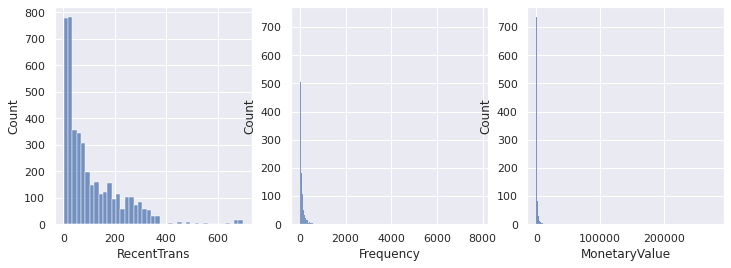

```
CPU times: user 5.73 s, sys: 61 ms, total: 5.79 s
Wall time: 5.81 s
```

```python
%%time
fig, ax = plt.subplots(1,3, figsize=(12,4))
for i, col in enumerate(df_rfm.columns):
    sns.histplot(df_rfm[col], ax=ax[i])
plt.show()
```

```python
skew_columns = (df_rfm.skew().sort_values(ascending=False))

skew_columns = skew_columns.loc[skew_columns > 0.75]
skew_columns
```

```
MonetaryValue    19.326985
Frequency        18.106243
RecentTrans       1.917516
dtype: float64
```

### Log Transformation

Perform transformation and check the transformed feature skewness. It is apparent that the features are no longer skewed.

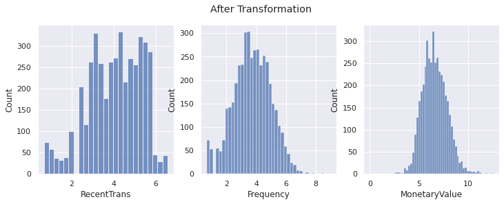

```
CPU times: user 1.06 s, sys: 13.9 ms, total: 1.07 s
Wall time: 1.07 s
```

```python
%%time
df_transf = df_rfm.copy()
for col in skew_columns.index.tolist():
    df_transf[col] = np.log1p(df_transf[col])


fig, ax = plt.subplots(1,3, figsize=(12,4))
for i, col in enumerate(df_transf.columns):
    sns.histplot(df_transf[col], ax=ax[i])
plt.suptitle('After Transformation')
plt.show()
```

Skewness of the transformed features are between -0.5 and 0.5, which is considered as fairly symmetrical

```python
(df_transf.skew().sort_values(ascending=False))
```

```
MonetaryValue    0.360562
Frequency       -0.015272
RecentTrans     -0.459898
dtype: float64
```

Feature statistics after Scaling. All have mean $\pm0$ and standard deviation $\pm1$

```python
scaler = StandardScaler()
df_train = df_transf.copy()
for col in df_transf.columns:
    df_train[col] = scaler.fit_transform(df_train[[col]])
df_train.describe().round(4)
```

|  | RecentTrans | Frequency | MonetaryValue |
| --- | --- | --- | --- |
| count | 4339.0000 | 4339.0000 | 4339.0000 |
| mean | 0.0000 | -0.0000 | 0.0000 |
| std | 1.0001 | 1.0001 | 1.0001 |
| min | -2.6679 | -2.4328 | -5.2266 |
| 25% | -0.6904 | -0.6764 | -0.6828 |
| 50% | 0.0776 | 0.0009 | -0.0608 |
| 75% | 0.8365 | 0.7023 | 0.6534 |
| max | 1.9926 | 4.1818 | 4.7184 |

## 5. Modelling

### Search for optimal number of clusters

Perform KMeans clustering with different number of clusters to search for the optimal clusters number. We will choose the number of clusters by

1. Elbow method

   Compare the inertia or the distortion the clusters number and choose the configuration that leads to lowest inertia or distortion. We will choose the clusters number *n* that after which point the distortion and inertia decreases only slowly compared to before, hence the 'elbow'.
1. Silhouette analysis Silhouette score ranges from -1 to +1 and indicates the separation distance of the clusters. A score of +1 means the sample is located far away from the neighboring cluster. A score of 0 means the sample is on the decision boundary. A score of -1 means the sample is clustered wrongly.

### Clusters number vs Inertia

It is hard to decide the optimal clusters number since there is no clear cut-off ('elbow') from the graph below.

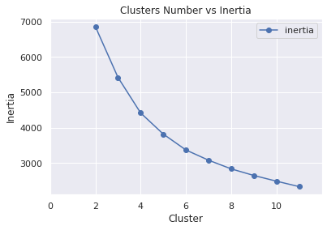

```python
### BEGIN SOLUTION
# Create and fit a range of models
km_list = []

for clust in range(2,12):
    km = KMeans(n_clusters=clust, random_state=26)
    km = km.fit(df_train)

    km_list.append(pd.Series({'clusters': clust,
                              'inertia': km.inertia_,
                              'model': km}))

plot_data = (pd.concat(km_list, axis=1)
             .T
             [['clusters','inertia']]
             .set_index('clusters'))

ax = plot_data.plot(marker='o',ls='-')
ax.set_xticks(range(0,12,2))
ax.set_xlim(0,12)
ax.set_title('Clusters Number vs Inertia')
ax.set(xlabel='Cluster', ylabel='Inertia');
### END SOLUTION
```

### Clusters number vs Distortion

It is hard to decide the optimal clusters number since there is no clear cut-off ('elbow') from the graph below.

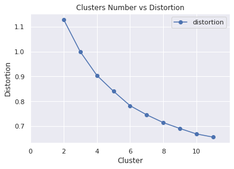

```python
### BEGIN SOLUTION
# Create and fit a range of models
km_list = []

for clust in range(2,12):
    km = KMeans(n_clusters=clust, random_state=26)
    km = km.fit(df_train)

    km_list.append(pd.Series({'clusters': clust,
                              'distortion': sum(np.min(cdist(df_train, km.cluster_centers_,
                                        'euclidean'), axis=1)) / df_train.shape[0],
                              'model': km}))

plot_data = (pd.concat(km_list, axis=1)
             .T
             [['clusters','distortion']]
             .set_index('clusters'))

ax = plot_data.plot(marker='o',ls='-')
ax.set_xticks(range(0,12,2))
ax.set_xlim(0,12)
ax.set_title('Clusters Number vs Distortion')
ax.set(xlabel='Cluster', ylabel='Distortion');
### END SOLUTION
```

### Clusters number vs Silhouette Score

We will plot the silhouette score of each cluster for different clusters number. The higher the score means the samples are more separated from the neighboring clusters. From the graphs below, the higher the clusters number, the smaller the silhouette score. The score is smaller than 0.3 when the `n_clusters` is 5 or higher. For these configurations, more samples are misclassified as we can see from the negative silhouette score. This suggests that `n_clusters` of 2, 3, 4 might be the best configuration.

```python
def plot_silhouette_analysis(X):
    for n_clusters in range(2,12):
        # Create a subplot with 1 row and 2 columns
        fig, ax = plt.subplots(1, 1)
        fig.set_size_inches(8, 7)

        # The 1st subplot is the silhouette plot
        # The silhouette coefficient can range from -1, 1 but in this example all
        # lie within [-0.1, 1]
        ax.set_xlim([-0.1, 1])
        # The (n_clusters+1)*10 is for inserting blank space between silhouette
        # plots of individual clusters, to demarcate them clearly.
        ax.set_ylim([0, len(X) + (n_clusters + 1) * 10])

        # Initialize the clusterer with n_clusters value and a random generator
        # seed of 10 for reproducibility.
        clusterer = KMeans(n_clusters=n_clusters, random_state=10)
        cluster_labels = clusterer.fit_predict(X)

        # The silhouette_score gives the average value for all the samples.
        # This gives a perspective into the density and separation of the formed
        # clusters
        silhouette_avg = silhouette_score(X, cluster_labels)
        print("For n_clusters =", n_clusters,
              "The average silhouette_score is :", silhouette_avg)

        # Compute the silhouette scores for each sample
        sample_silhouette_values = silhouette_samples(X, cluster_labels)

        y_lower = 10
        for i in range(n_clusters):
            # Aggregate the silhouette scores for samples belonging to
            # cluster i, and sort them
            ith_cluster_silhouette_values = \
                sample_silhouette_values[cluster_labels == i]

            ith_cluster_silhouette_values.sort()

            size_cluster_i = ith_cluster_silhouette_values.shape[0]
            y_upper = y_lower + size_cluster_i

            color = cm.nipy_spectral(float(i) / n_clusters)
            ax.fill_betweenx(np.arange(y_lower, y_upper),
                              0, ith_cluster_silhouette_values,
                              facecolor=color, edgecolor=color, alpha=0.7)

            # Label the silhouette plots with their cluster numbers at the middle
            ax.text(-0.05, y_lower + 0.5 * size_cluster_i, str(i))

            # Compute the new y_lower for next plot
            y_lower = y_upper + 10  # 10 for the 0 samples

        ax.set_title("The silhouette plot for the various clusters.")
        ax.set_xlabel("The silhouette coefficient values")
        ax.set_ylabel("Cluster label")

        # The vertical line for average silhouette score of all the values
        ax.axvline(x=silhouette_avg, color="red", linestyle="--")

        ax.set_yticks([])  # Clear the yaxis labels / ticks
        ax.set_xticks([-0.1, 0, 0.2, 0.4, 0.6, 0.8, 1])

        plt.suptitle(("Silhouette analysis for KMeans clustering on sample data "
                      "with n_clusters = %d" % n_clusters),
                    fontsize=14, fontweight='bold')
```

```
For n_clusters = 2 The average silhouette_score is : 0.3984490807520717
For n_clusters = 3 The average silhouette_score is : 0.2939590856452589
For n_clusters = 4 The average silhouette_score is : 0.30291276600135514
For n_clusters = 5 The average silhouette_score is : 0.27245225104697063
For n_clusters = 6 The average silhouette_score is : 0.2737323249390449
For n_clusters = 7 The average silhouette_score is : 0.25892865078041044
For n_clusters = 8 The average silhouette_score is : 0.26337085947019967
For n_clusters = 9 The average silhouette_score is : 0.2546326149342129
For n_clusters = 10 The average silhouette_score is : 0.26142348677931965
For n_clusters = 11 The average silhouette_score is : 0.2618187678581975
```

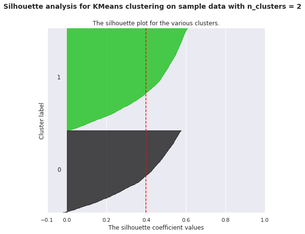

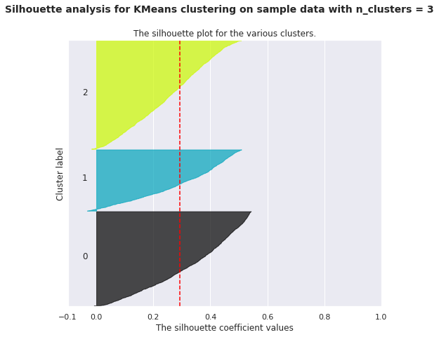

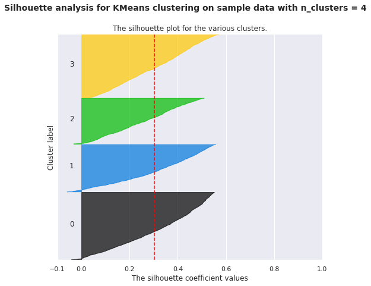

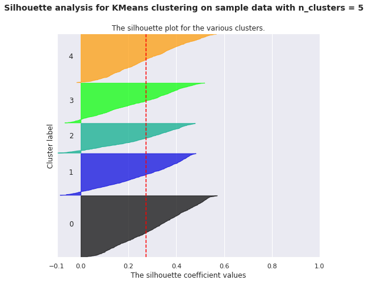

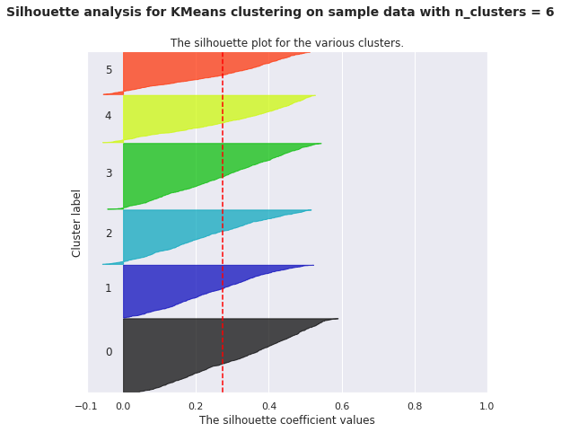

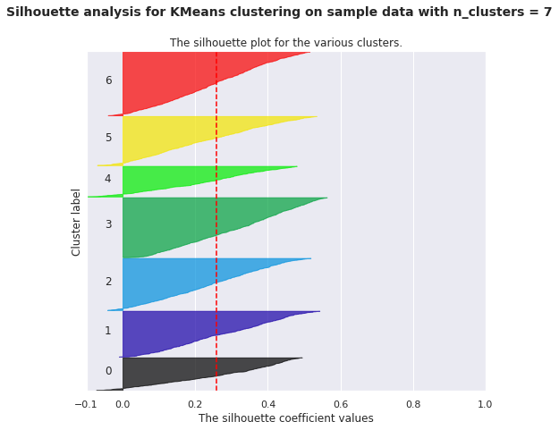

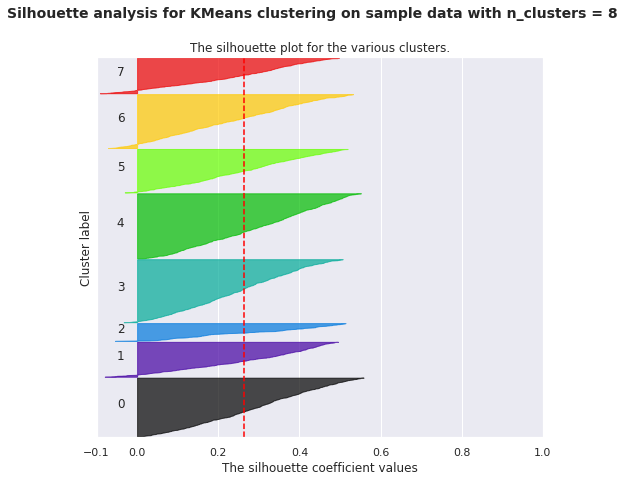

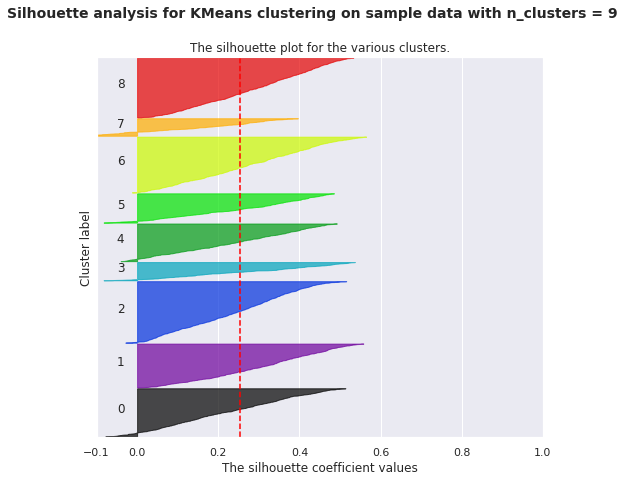

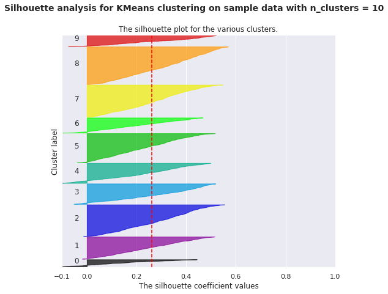

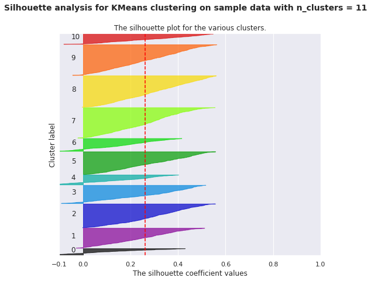

```python
plot_silhouette_analysis(df_train)
plt.show()
```

### KMeans vs Hierarchical Agglomerative Clustering

We will try both clustering methods with clusters number of 2, 3, and 4. We map our data that contains 3 features to a lower dimension (2) using t-SNE to visualize them in 2D plot.

```python
def kmeans(df, clusters_number):
    '''
    Implement k-means clustering on dataset

    INPUT:
        dataset : dataframe. Dataset for k-means to fit.
        clusters_number : int. Number of clusters to form.
        end : int. Ending range of kmeans to test.
    OUTPUT:
        Cluster results and t-SNE visualisation of clusters.
    '''

    kmeans = KMeans(n_clusters = clusters_number, random_state = 1)
    kmeans.fit(df)

    # Extract cluster labels
    cluster_labels = kmeans.labels_

    # Create a cluster label column in original dataset
    df_new = df.assign(Cluster = cluster_labels)

    # Initialise TSNE
    model = TSNE(random_state=1)
    transformed = model.fit_transform(df)

    # Plot t-SNE
    plt.title('Flattened Graph of {} Clusters'.format(clusters_number))
    sns.scatterplot(x=transformed[:,0], y=transformed[:,1], hue=cluster_labels, style=cluster_labels, palette="Set1")

    return df_new, cluster_labels
```

```python
def plot_ag(df, clusters_number, df_agg):

    # kmeans = KMeans(n_clusters = clusters_number, random_state = 1)
    # kmeans.fit(df)

    # # Extract cluster labels
    # cluster_labels = kmeans.labels_

    # # Create a cluster label column in original dataset
    # df_new = df.assign(Cluster = cluster_labels)

    # Initialise TSNE
    cluster_labels = df_agg['Cluster']

    model = TSNE(random_state=1)
    transformed = model.fit_transform(df)

    # Plot t-SNE
    plt.title('Flattened Graph of {} Clusters'.format(clusters_number))
    sns.scatterplot(x=transformed[:,0], y=transformed[:,1], hue=cluster_labels, style=cluster_labels, palette="Set1")
```

### Clusters Number = 2, (KMeans (top) vs AgglomerativeClustering (bottom))

For clusters number = 2, the cluster assignment in KMeans and AgglomerativeClustering doesn't look very different

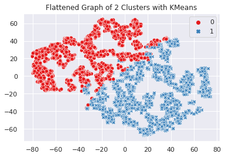

```
CPU times: user 1min 3s, sys: 410 ms, total: 1min 3s
Wall time: 32.6 s
```

```python
%%time
df_km_2, labels_2 = kmeans(df_train, 2)
df_label_2 = df_rfm.assign(Cluster = labels_2)
plt.title('Flattened Graph of 2 Clusters with KMeans')
plt.show()
```

```python
ag = AgglomerativeClustering(n_clusters=2, linkage='ward')
ag = ag.fit(df_train)
cluster_labels = ag.fit_predict(df_train)
df_agg_2 = df_train.assign(Cluster = cluster_labels)
```

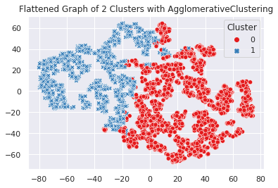

```python
plot_ag(df_train, clusters_number=2, df_agg=df_agg_2)
plt.title('Flattened Graph of 2 Clusters with AgglomerativeClustering')
plt.show()
```

### Clusters Number = 3, (KMeans (top) vs AgglomerativeClustering (bottom))

For clusters number = 3, it is apparent that KMeans groups the data differently compared with AgglomerativeClustering, as we can see from the cluster assignment. The clusters in KMeans are more nicely separated than the one in AgglomerativeClustering.

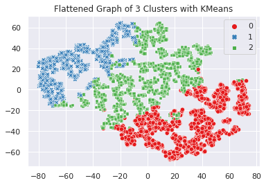

```
CPU times: user 1min 2s, sys: 496 ms, total: 1min 3s
Wall time: 32.2 s
```

```python
%%time
df_km_3, labels_3 = kmeans(df_train, 3)
df_label_3 = df_rfm.assign(Cluster = labels_3)
plt.title('Flattened Graph of 3 Clusters with KMeans')
plt.show()
```

```python
ag = AgglomerativeClustering(n_clusters=3, linkage='ward')
ag = ag.fit(df_train)
cluster_labels = ag.fit_predict(df_train)
df_agg_3 = df_train.assign(Cluster = cluster_labels)
```

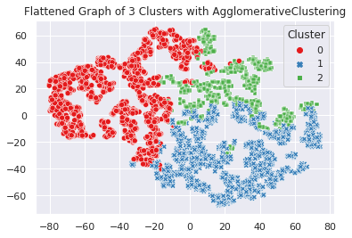

```python
plot_ag(df_train, clusters_number=3, df_agg=df_agg_3)
plt.title('Flattened Graph of 3 Clusters with AgglomerativeClustering')
plt.show()
```

### Clusters Number = 4, (KMeans (top) vs AgglomerativeClustering (bottom))

For clusters number = 4, we can also see the difference in cluster assignment for KMeans and AgglomerativeClustering. Here, too, the clusters are more nicely separated in KMeans compared with in AgglomerativeClustering.

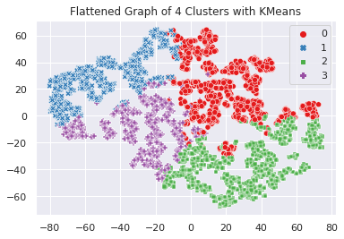

```
CPU times: user 1min 3s, sys: 412 ms, total: 1min 3s
Wall time: 32.6 s
```

```python
%%time
df_km_4, labels_4 = kmeans(df_train, 4)
df_label_4 = df_rfm.assign(Cluster = labels_4)
plt.title('Flattened Graph of 4 Clusters with KMeans')
plt.show()
```

```python
ag = AgglomerativeClustering(n_clusters=4, linkage='ward')
ag = ag.fit(df_train)
cluster_labels = ag.fit_predict(df_train)
df_agg_4 = df_train.assign(Cluster = cluster_labels)
```

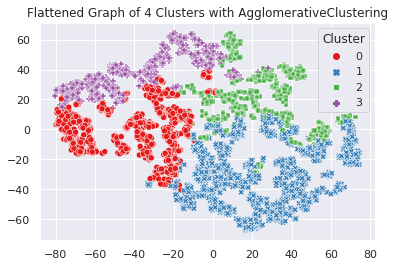

```
CPU times: user 1min 2s, sys: 273 ms, total: 1min 2s
Wall time: 32.1 s
```

```python
%%time
plot_ag(df_train, clusters_number=4, df_agg=df_agg_4)
plt.title('Flattened Graph of 4 Clusters with AgglomerativeClustering')
plt.show()
```

Based on the flattened graphs above, we conclude that KMeans is better at grouping our dataset.

## 6. Customer Segmentation Result

We can make a snake plot for the cluster against the value for Recency (`RecentTrans`), Frequency (`Frequency`), and Monetary (`MonetaryValue`) to see how the cluster differs from each other.

We can differentiate the Recency, Frequency, and Monetary values into (roughly) low, med, and high level for all clusters number.

From KMeans clustering with $k=3$:

```python
def snake_plot(normalised_df_rfm, df_rfm_kmeans, df_rfm_original=df_rfm):
    '''
    Transform dataframe and plot snakeplot
    '''
    # Transform df_normal as df and add cluster column
    normalised_df_rfm = pd.DataFrame(normalised_df_rfm,
                                       index=df_rfm_original.index,
                                       columns=df_rfm_original.columns)
    normalised_df_rfm['Cluster'] = df_rfm_kmeans['Cluster']

    # Melt data into long format
    df_melt = pd.melt(normalised_df_rfm.reset_index(),
                        id_vars=['CustomerID', 'Cluster'],
                        value_vars=['RecentTrans', 'Frequency', 'MonetaryValue'],
                        var_name='Metric',
                        value_name='Value')

    plt.xlabel('Metric')
    plt.ylabel('Value')

    return sns.pointplot(data=df_melt, x='Metric', y='Value', hue='Cluster')
```

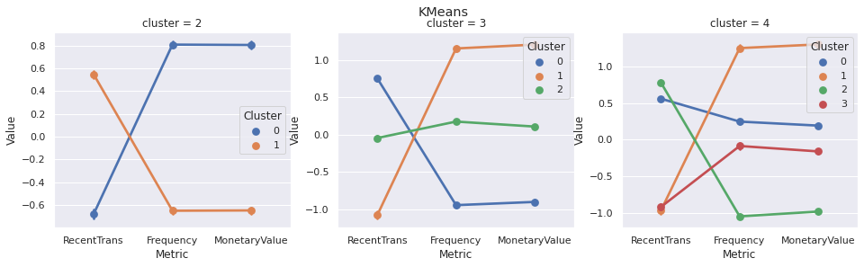

```
CPU times: user 1.91 s, sys: 17.4 ms, total: 1.92 s
Wall time: 1.93 s
```

```python
%%time
fig, ax = plt.subplots(1,3, figsize=(16,4))
plt.subplot(1,3,1)
ax[0]=snake_plot(df_train, df_km_2)
ax[0].set_title('cluster = 2')
plt.subplot(1,3,2)
ax[1]=snake_plot(df_train, df_km_3)
ax[1].set_title('cluster = 3')
plt.subplot(1,3,3)
ax[2]=snake_plot(df_train, df_km_4)
ax[2].set_title('cluster = 4')
plt.suptitle('KMeans')
plt.show()
```

```python
def rfm_values(df):
    '''
    Calcualte average RFM values and size for each cluster

    '''
    df_new = df.groupby(['Cluster']).agg({
        'RecentTrans': 'mean',
        'Frequency': 'mean',
        'MonetaryValue': ['mean', 'count']
    }).round(0)

    return df_new
```

```python
rfm_values(df_label_3)
```

| Cluster | RecentTrans mean | Frequency mean | MonetaryValue mean | MonetaryValue count |
| --- | --- | --- | --- | --- |
| 0 | 194.0 | 16.0 | 303.0 | 1552 |
| 1 | 21.0 | 258.0 | 6419.0 | 1005 |
| 2 | 78.0 | 64.0 | 1117.0 | 1782 |

## 7. Conclusion and Suggestion

For a better Recency feature in the next analysis, we might consider calculate the duration between purchase and customer's first purchase, not only the duration from their last purchase.